# Estimation

On this noteboook, we will explore different estimation methods on species diversification processes. We will focuss on estimating on the PD model

The Phylogenetic Diversification (PD) model describes the speciation rate over time within a phylogenetic tree. The model takes into account both speciation and extinction events, and it can be mathematically described by the following equations:

The speciation rate $\lambda_s(t)$ at time $t$ is given by:

$$\lambda_s(t | \lambda_0, \beta_N, \beta_P) = \max \left( 0, \lambda_0 +
\beta_N N_t + \beta_P \frac{P_t}{N_t} \right);$$

where:

- $\lambda_0$ is the baseline speciation rate,
- $\beta_N$ is the coefficient for the effect of the number of lineages at time $t$ (denoted $N_t$),
- $\beta_P$ is the coefficient for the effect of the phylogenetic diversity at time $t$ (denoted $P_t$), normalized by the number of lineages $N_t$.

The extinction rate $\mu_s(t)$ is assumed to be constant over time, denoted by $\mu_0$:

$$\mu_s(t | \mu_0) = \mu_0$$

The PD model ensures that the speciation rate is non-negative and allows for the simulation of complex evolutionary scenarios.

```r
getwd()
```

```
[1] "/Users/pancho/Library/CloudStorage/Dropbox/github/emphasis/Documentation"
```

[figure not shown]

```r
#load("FamilyBirdTrees.Rdata")
phylo = FamilyBirdTrees$Parulidae$tree
ape:::plot.phylo(phylo)
```

Phylogenies that are derived from molecular data (e.g. DNA sequences) are, however, not full trees, as they do not contain the extinct species. The likelihood for an observed tree can be written in terms of the likelihood of compatible full trees. In principle, this is simply the integration over all possible full trees that are compatible with the observed tree $x_{obs}$:

$$\begin{equation}
f(x_{obs}|\theta) = \displaystyle\int_{x \in
\mathcal{X}(x_{obs})} \exp(\ell _{x} (\theta|x_{obs})) dx
\label{logy}
\end{equation}$$

This integration is usually impossible to compute in practice for most diversification models ($\ref{logy}$). We can obtain a numerical approximation by using the Monte-Carlo approach considering

### Likelihood function

```
Loading data...Data loaded[1] "Simulation took  1 hours, 6 minutes and 5 seconds"
[1] "betaN_interval1 : -0.01"
[1] "betaN_interval2 : 0"
[1] "betaP_interval1 : -0.02"
[1] "betaP_interval2 : 0.02"
[1] "lambda_interval1 : 0.5"
[1] "lambda_interval2 : 1"
[1] "max_lin : 10000"
[1] "max_tries : 10"
[1] "mu_interval1 : 0"
[1] "mu_interval2 : 0.2"
[1] "n_trees : 1e+06"
[1] "phylo_name : Parulidae"
Extracting trees information...Number of simulations attempted: 1000000
Number of simulations completed successfully: 718334
Creating plots, this might take a while...
```

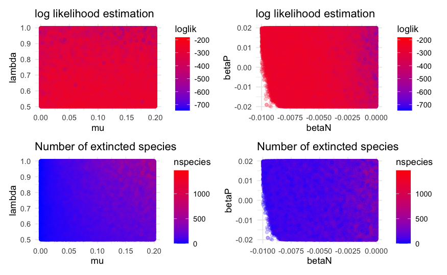

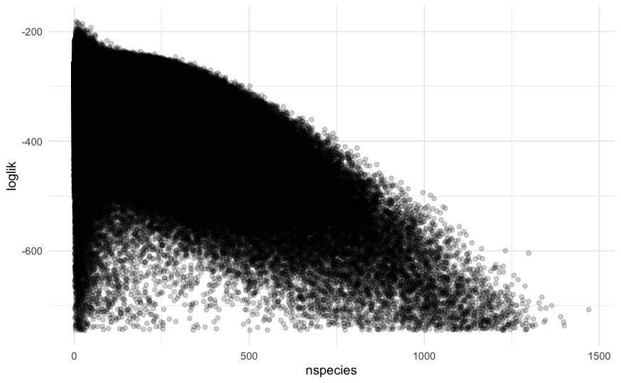

```r
# load simulation data
path_data = "~/Library/CloudStorage/Dropbox/Pancho/78 - GAM paper/01 - Simulation data/Parulidae_20240205_233041.RData"
process_and_plot(path_data)
```

```r
class(results)
```

```
[1] "list"
```